# 1 Setup and reproducibility

# 7 DQN baseline setup

Prepares the deep Q-learning machinery for the original environment. It defines a simple feedforward Q-network that takes the flattened clinic state as input and outputs Q-values for each overbooking action. A replay buffer, ε-greedy action selection, and a target network are implemented to stabilize training. Learning hyperparameters such as learning rate, discount factor, replay capacity, batch size, and epsilon schedule are set to reasonable defaults. This creates a reusable DQN training scaffold that later sections can plug into different objectives and configurations.

```python
Transition = collections.namedtuple("Transition", ("s","a","r","s2","done"))

class ReplayBuffer:
    def __init__(self, capacity=50_000, seed=SEED):
        self.buf = collections.deque(maxlen=capacity)
        self.rng = np.random.default_rng(seed)
    def __len__(self):
        return len(self.buf)
    def push(self, s,a,r,s2,done):
        self.buf.append(Transition(s,a,r,s2,done))
    def sample(self, batch):
        idx = self.rng.integers(0, len(self.buf), size=batch)
        batch = [self.buf[i] for i in idx]
        s  = torch.tensor(np.stack([t.s  for t in batch]), dtype=torch.float32, device=device)
        a  = torch.tensor([t.a for t in batch], dtype=torch.long, device=device).unsqueeze(1)
        r  = torch.tensor([t.r for t in batch], dtype=torch.float32, device=device).unsqueeze(1)
        s2 = torch.tensor(np.stack([t.s2 for t in batch]), dtype=torch.float32, device=device)
        d  = torch.tensor([t.done for t in batch], dtype=torch.float32, device=device).unsqueeze(1)
        return s,a,r,s2,d

class QNet(nn.Module):
    def __init__(self, obs_dim: int, n_actions: int):
        super().__init__()
        self.net = nn.Sequential(
            nn.Linear(obs_dim, 128), nn.ReLU(),
            nn.Linear(128, 128), nn.ReLU(),
            nn.Linear(128, n_actions)
        )
    def forward(self, x):
        return self.net(x)

def dqn_epsilon(step, eps_start=1.0, eps_end=0.05, eps_decay_steps=20_000):
    t = min(1.0, step / float(eps_decay_steps))
    return eps_start + t * (eps_end - eps_start)

@torch.no_grad()
def select_action(qnet: QNet, obs: np.ndarray, env: ClinicEnv, eps: float) -> int:
    if np.random.random() < eps:
        return env.action_space.sample()
    x = torch.tensor(obs, dtype=torch.float32, device=device).unsqueeze(0)
    q = qnet(x)
    return int(q.argmax(1).item())

def train_step(qnet, tgt, opt, batch, gamma=0.99):
    s,a,r,s2,d = batch
    q = qnet(s).gather(1, a)  # Q(s,a)
    with torch.no_grad():
        q_next = tgt(s2).max(1, keepdim=True)[0]
        y = r + (1.0 - d) * gamma * q_next
    loss = nn.functional.smooth_l1_loss(q, y)
    opt.zero_grad()
    loss.backward()
    nn.utils.clip_grad_norm_(qnet.parameters(), 1.0)
    opt.step()
    return float(loss.item())

def run_dqn(env_cfg: ClinicConfig,
            steps_total=40_000,
            batch_size=64,
            start_learning=1000,
            target_sync=2000,
            gamma=0.99,
            lr=1e-3):
    env = ClinicEnv(env_cfg)
    obs_dim = env.observation_space.shape[0]
    n_actions = env.action_space.n

    qnet = QNet(obs_dim, n_actions).to(device)
    tgt  = QNet(obs_dim, n_actions).to(device)
    tgt.load_state_dict(qnet.state_dict())
    opt = optim.Adam(qnet.parameters(), lr=lr)

    buf = ReplayBuffer(capacity=50_000, seed=SEED)

    obs, _ = env.reset()
    episode_reward = 0.0
    rewards = []
    losses = []
    episodes = 0

    for step in range(1, steps_total + 1):
        eps = dqn_epsilon(step)
        a = select_action(qnet, obs, env, eps)
        obs2, r, term, trunc, info = env.step(a)
        buf.push(obs.astype(np.float32), a, r, obs2.astype(np.float32), float(term or trunc))
        obs = obs2
        episode_reward += r

        if term or trunc:
            rewards.append(episode_reward)
            episodes += 1
            episode_reward = 0.0
            obs, _ = env.reset()

        if len(buf) >= start_learning:
            loss = train_step(qnet, tgt, opt, buf.sample(batch_size), gamma=gamma)
            losses.append(loss)

        if step % target_sync == 0:
            tgt.load_state_dict(qnet.state_dict())

    return qnet, {"rewards": np.array(rewards, dtype=np.float32),
                  "losses": np.array(losses, dtype=np.float32)}

@torch.no_grad()
def evaluate_greedy(qnet: QNet, env_cfg: ClinicConfig, episodes=256):
    env = ClinicEnv(env_cfg)
    def greedy(obs, env):  # no exploration
        x = torch.tensor(obs, dtype=torch.float32, device=device).unsqueeze(0)
        q = qnet(x)
        return int(q.argmax(1).item())
    rows = [run_episode(env, greedy) for _ in range(episodes)]
    return pd.DataFrame(rows)
```

# 8 DQN training and evaluation

Using the setup from Section 7, this section trains a DQN agent directly on the original `ClinicEnv`. Training logs record episode returns and losses so that learning curves can be plotted. After training, the learned policy is run greedily over many episodes to estimate its mean cost, risk metrics, and throughput. These results are compared against the heuristic baselines to see whether model-free deep RL can discover a better overbooking policy in the original toy setting.

```
step=     1  eps=1.000  replay=     1  loss~=nan  episodes=   0  elapsed=0.0m
step=  2000  eps=0.905  replay=  2000  loss~=5.6219  episodes=  62  elapsed=0.1m
step=  4000  eps=0.810  replay=  4000  loss~=5.3102  episodes= 125  elapsed=0.2m
step=  6000  eps=0.715  replay=  6000  loss~=8.0851  episodes= 187  elapsed=0.3m
step=  8000  eps=0.620  replay=  8000  loss~=10.2307  episodes= 250  elapsed=0.4m
step= 10000  eps=0.525  replay= 10000  loss~=13.7647  episodes= 312  elapsed=0.5m
step= 12000  eps=0.430  replay= 12000  loss~=14.5870  episodes= 375  elapsed=0.6m
step= 14000  eps=0.335  replay= 14000  loss~=16.3694  episodes= 437  elapsed=0.7m
step= 16000  eps=0.240  replay= 16000  loss~=20.7460  episodes= 500  elapsed=0.8m
step= 18000  eps=0.145  replay= 18000  loss~=18.0429  episodes= 562  elapsed=1.0m
step= 20000  eps=0.050  replay= 20000  loss~=18.9678  episodes= 625  elapsed=1.1m
step= 22000  eps=0.050  replay= 22000  loss~=24.1006  episodes= 687  elapsed=1.2m
step= 24000  eps=0.050  replay= 24000  loss~=30.3531  episodes= 750  elapsed=1.3m
step= 26000  eps=0.050  replay= 26000  loss~=30.5867  episodes= 812  elapsed=1.4m
step= 28000  eps=0.050  replay= 28000  loss~=26.9236  episodes= 875  elapsed=1.5m
step= 30000  eps=0.050  replay= 30000  loss~=26.6242  episodes= 937  elapsed=1.6m
step= 32000  eps=0.050  replay= 32000  loss~=31.9393  episodes=1000  elapsed=1.7m
step= 34000  eps=0.050  replay= 34000  loss~=31.7919  episodes=1062  elapsed=1.8m
step= 36000  eps=0.050  replay= 36000  loss~=26.3579  episodes=1125  elapsed=1.9m
step= 38000  eps=0.050  replay= 38000  loss~=28.4677  episodes=1187  elapsed=2.0m
step= 40000  eps=0.050  replay= 40000  loss~=33.0066  episodes=1250  elapsed=2.1m
Saved: report_artifacts/dqn_rewards_20251124_210736.png
                policy    mean_cost  mean_cost_ci_lo  mean_cost_ci_hi  \
1                  dqn  1346.261719      1279.338013      1412.855347
3          no_overbook  1346.261719      1279.338013      1412.855347
4               random  3227.937988      3123.317139      3334.961182
2        mild_overbook  3240.602051      3143.454102      3335.838135
0  aggressive_overbook  3338.376953      3231.224854      3447.524902

          var5        cvar5     served
1  2241.324951  2504.346191  55.109375
3  2241.324951  2504.346191  55.109375
4  4695.099609  5091.846191  62.031250
2  4625.699707  4784.246094  62.167969
0  4741.875000  5107.530762  62.218750
Saved: report_artifacts/dqn_vs_baselines_20251124_210739.png
```

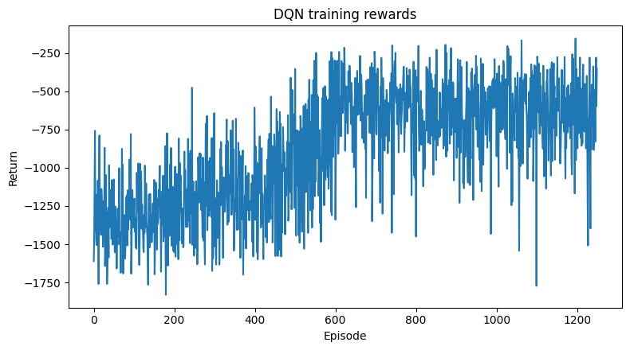

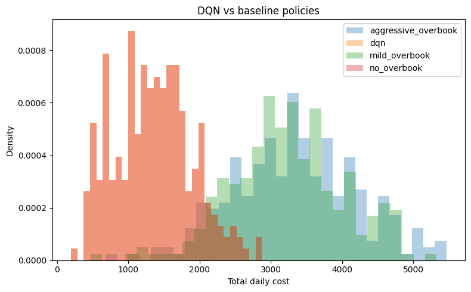

```python
def run_dqn(env_cfg: ClinicConfig,
            steps_total=40_000,
            batch_size=64,
            start_learning=1_000,
            target_sync=2_000,
            gamma=0.99,
            lr=1e-3,
            print_every=2_000):
    env = ClinicEnv(env_cfg)
    obs_dim = env.observation_space.shape[0]
    n_actions = env.action_space.n

    qnet = QNet(obs_dim, n_actions).to(device)
    tgt  = QNet(obs_dim, n_actions).to(device)
    tgt.load_state_dict(qnet.state_dict())
    opt = optim.Adam(qnet.parameters(), lr=lr)

    buf = ReplayBuffer(capacity=50_000, seed=SEED)

    obs, _ = env.reset()
    episode_reward = 0.0
    rewards = []
    losses = []
    episodes = 0
    t0 = time.time()
    rolling_loss = None

    for step in range(1, steps_total + 1):
        eps = dqn_epsilon(step, eps_start=1.0, eps_end=0.05, eps_decay_steps=20_000)
        a = select_action(qnet, obs, env, eps)
        obs2, r, term, trunc, _ = env.step(a)
        buf.push(obs.astype(np.float32), a, r, obs2.astype(np.float32), float(term or trunc))
        obs = obs2
        episode_reward += r

        if term or trunc:
            rewards.append(episode_reward)
            episodes += 1
            episode_reward = 0.0
            obs, _ = env.reset()

        if len(buf) >= start_learning:
            loss = train_step(qnet, tgt, opt, buf.sample(batch_size), gamma=gamma)
            losses.append(loss)
            rolling_loss = (0.9 * rolling_loss + 0.1 * loss) if rolling_loss is not None else loss

        if step % target_sync == 0:
            tgt.load_state_dict(qnet.state_dict())

        if step % print_every == 0 or step == 1:
            elapsed_min = (time.time() - t0) / 60.0
            print(f"step={step:6d}  eps={eps:0.3f}  replay={len(buf):6d}  "
                  f"loss~={(rolling_loss if rolling_loss is not None else float('nan')):0.4f}  "
                  f"episodes={episodes:4d}  elapsed={elapsed_min:0.1f}m")

    return qnet, {"rewards": np.array(rewards, dtype=np.float32),
                  "losses": np.array(losses, dtype=np.float32)}

# Train
qnet_dqn, logs_dqn = run_dqn(cfg,
                             steps_total=40_000,
                             batch_size=64,
                             start_learning=1_000,
                             target_sync=2_000,
                             gamma=0.99,
                             lr=1e-3,
                             print_every=2_000)

# Plot training rewards
plt.figure(figsize=(8,4.5))
plt.plot(logs_dqn["rewards"])
plt.xlabel("Episode")
plt.ylabel("Return")
plt.title("DQN training rewards")
plt.tight_layout()
path_rewards = os.path.join(ART_DIR, f"dqn_rewards_{now_tag()}.png")
plt.savefig(path_rewards, dpi=120)
print("Saved:", path_rewards)

# Evaluate greedy DQN policy
df_dqn = evaluate_greedy(qnet_dqn, cfg, episodes=256)

# Summarize like baselines
df_all = pd.concat([df_base, df_dqn.assign(policy="dqn")], ignore_index=True)
summary_all = summarize(df_all, alpha=0.05)
print(summary_all.sort_values("mean_cost"))

# Distribution plot
plt.figure(figsize=(8,5))
for name, g in df_all.groupby("policy"):
    if name in ["dqn","no_overbook","mild_overbook","aggressive_overbook"]:
        plt.hist(g["cost_total"], bins=30, alpha=0.35, density=True, label=name)
plt.xlabel("Total daily cost")
plt.ylabel("Density")
plt.title("DQN vs baseline policies")
plt.legend()
plt.tight_layout()
path_hist2 = os.path.join(ART_DIR, f"dqn_vs_baselines_{now_tag()}.png")
plt.savefig(path_hist2, dpi=120)
print("Saved:", path_hist2)
```

```
Saved: report_artifacts/ecdf_costs_20251124_210740.png
```

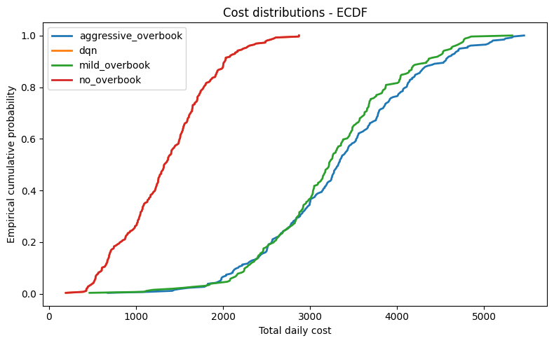

```python
def ecdf(y: np.ndarray) -> tuple[np.ndarray, np.ndarray]:
    y = np.sort(y.astype(np.float32))
    x = np.linspace(0.0, 1.0, len(y), endpoint=False) + 1.0/len(y)
    return y, x

color_map = {
    "aggressive_overbook": "C0",
    "dqn": "C1",
    "mild_overbook": "C2",
    "no_overbook": "C3",
}

plt.figure(figsize=(8,5))
for name, g in df_all.groupby("policy"):
    if name not in color_map:
        continue
    y, x = ecdf(g["cost_total"].to_numpy())
    plt.plot(y, x, label=name, linewidth=2.0, color=color_map[name])

plt.xlabel("Total daily cost")
plt.ylabel("Empirical cumulative probability")
plt.title("Cost distributions - ECDF")
plt.legend()
plt.tight_layout()
path_ecdf = os.path.join(ART_DIR, f"ecdf_costs_{now_tag()}.png")
plt.savefig(path_ecdf, dpi=120)
print("Saved:", path_ecdf)
```

# 9 Objective patch (add revenue and a throughput target)

Upgrades the economic model into a more realistic objective, referred to as Env V2. It extends the environment so that each served patient generates revenue, while overtime work and unserved demand incur explicit penalties. The new objective combines these components into a daily total cost under “V2 units” that trade off revenue, overtime, and shortfall in a clinically meaningful way. The environment code is patched so that every step and every episode now track both the original cost and the new V2 cost, preparing the ground for all subsequent experiments to be evaluated under the richer objective.

```python
cfg.revenue_per_patient = 50.0          # money earned per served patient
cfg.throughput_target = 60              # soft daily target for served patients
cfg.throughput_shortfall_penalty = 30.0 # per missing patient below target
cfg.no_show_slope = 0.08                # make later slots a bit riskier than before

class ClinicEnvV2(ClinicEnv):
    """
    Extends ClinicEnv with revenue for each served patient and a soft penalty
    if total served falls below a target at the end of the day.
    Reward shaping uses total_cost = costs - revenue + penalties.
    """
    def __init__(self, cfg: ClinicConfig):
        super().__init__(cfg)
        # extra accounting
        self.revenue_accum = 0.0
        self.shortfall_penalty_accum = 0.0
        self._served_prev = 0

    def reset(self, *, seed=None, options=None):
        obs, info = super().reset(seed=seed, options=options)
        self.revenue_accum = 0.0
        self.shortfall_penalty_accum = 0.0
        self._served_prev = 0
        return obs, info

    def step(self, action: int):
        # Run original step
        obs_before = self._obs()
        served_before = self.patients_served
        obs, reward, terminated, truncated, info = super().step(action)

        # Revenue for newly completed services this step
        served_now = self.patients_served
        delta_served = max(0, served_now - served_before)
        if delta_served > 0:
            self.revenue_accum += delta_served * float(getattr(self.cfg, "revenue_per_patient", 0.0))

        # If episode ended apply throughput shortfall penalty once
        if terminated or truncated:
            shortfall = max(0, int(getattr(self.cfg, "throughput_target", 0)) - int(self.patients_served))
            if shortfall > 0:
                self.shortfall_penalty_accum += shortfall * float(getattr(self.cfg, "throughput_shortfall_penalty", 0.0))

        # Replace reward with negative total cost proxy that includes revenue and penalty
        reward = - self._instant_cost_proxy_v2()

        # Update info with new terms
        info = dict(info)
        info["revenue"] = self.revenue_accum
        info["shortfall_penalty"] = self.shortfall_penalty_accum
        info["cost_total_v2"] = self._total_cost_v2()

        return obs, reward, terminated, truncated, info

    def _total_cost_v2(self) -> float:
        raw_costs = self.cost_wait + self.cost_overtime + self.cost_idle + self.cost_no_show
        return raw_costs - self.revenue_accum + self.shortfall_penalty_accum

    def _instant_cost_proxy_v2(self) -> float:
        slots_passed = max(1, self.slot_idx)
        return self._total_cost_v2() / slots_passed

# Quick smoke test on the new objective
env2 = ClinicEnvV2(cfg)
rec = run_episode(env2, policy_no_overbook)
print("V2 objective check (served):", rec["patients_served"],
      " total raw cost:", rec["cost_total"])
```

```
V2 objective check (served): 56  total raw cost: 1663.1
```

# 10 Baseline heuristics on the new objective

```
                policy  mean_cost_v2  mean_cost_v2_ci_lo  mean_cost_v2_ci_hi  \
2          no_overbook  -1311.346069        -1364.624878        -1253.996094
3               random    -19.555077         -108.202988           67.663124
1        mild_overbook    -13.819134          -90.508011           67.095917
0  aggressive_overbook    102.382812            8.918678          191.141724

       var5_v2     cvar5_v2     served  mean_revenue  mean_shortfall_penalty
2  -471.300018  -169.438461  54.148438   2707.421875              175.898438
3  1198.199951  1585.430786  60.984375   3049.218750               24.843750
1  1253.274902  1578.853760  60.859375   3042.968750               26.953125
0  1403.125000  1738.099854  61.007812   3050.390625               23.554688
Saved: report_artifacts/ecdf_costs_envv2_20251124_210742.png
```

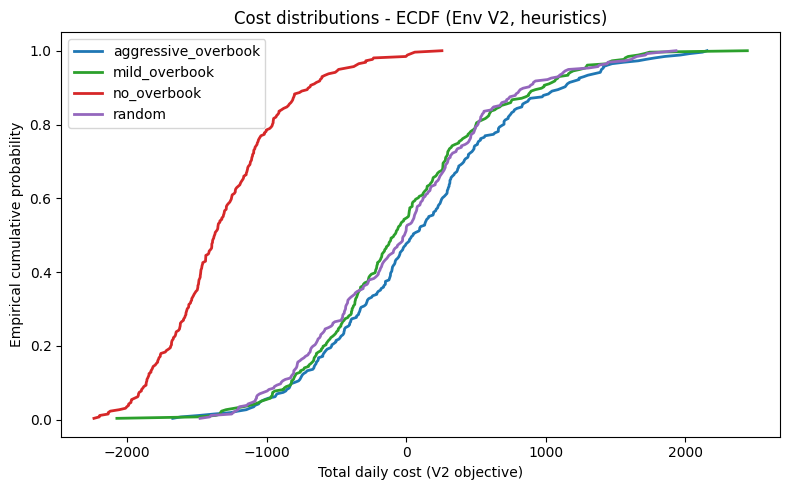

```python
def run_episode_v2(env: ClinicEnvV2, policy_fn):
    """
    Same as run_episode but also captures Env V2 fields and computes cost_total_v2.
    """
    obs, info = env.reset()
    total_reward = 0.0
    while True:
        a = policy_fn(obs, env)
        obs, r, terminated, truncated, info = env.step(a)
        total_reward += float(r)
        if terminated or truncated:
            break

    # Base metrics
    out = dict(
        reward=total_reward,
        cost_wait=float(info.get("cost_wait", 0.0)),
        cost_overtime=float(info.get("cost_overtime", 0.0)),
        cost_idle=float(info.get("cost_idle", 0.0)),
        cost_no_show=float(info.get("cost_no_show", 0.0)),
        patients_served=int(info.get("patients_served", 0)),
        patients_arrived=int(info.get("patients_arrived", 0)),
    )
    out["cost_total"] = out["cost_wait"] + out["cost_overtime"] + out["cost_idle"] + out["cost_no_show"]

    # Env V2 additions
    rev   = float(info.get("revenue", 0.0))
    pen   = float(info.get("shortfall_penalty", 0.0))

    cost2 = float(info.get("cost_total_v2", out["cost_total"] - rev + pen))

    out["revenue"] = rev
    out["shortfall_penalty"] = pen
    out["cost_total_v2"] = cost2
    return out

def eval_policies_v2(env_cfg: ClinicConfig, policies, episodes: int = 256) -> pd.DataFrame:
    rows = []
    for name, pi in policies.items():
        env = ClinicEnvV2(env_cfg)
        for _ in range(episodes):
            rec = run_episode_v2(env, pi)
            rec["policy"] = name
            rows.append(rec)
    return pd.DataFrame(rows)

df_base_v2 = eval_policies_v2(cfg, POLICIES, episodes=256)

def summarize_v2(df: pd.DataFrame, alpha: float = 0.05) -> pd.DataFrame:
    """
    Summarize using the V2 objective (cost_total_v2). Also report served, revenue, and penalty.
    """
    out = []
    for name, g in df.groupby("policy"):
        x = g["cost_total_v2"].to_numpy(np.float32)
        v, c = var_cvar(x, alpha=alpha)
        lo, hi = bootstrap_ci(x, np.mean, B=800, alpha=alpha)
        out.append(dict(
            policy=name,
            mean_cost_v2=float(x.mean()),
            mean_cost_v2_ci_lo=float(lo),
            mean_cost_v2_ci_hi=float(hi),
            var5_v2=float(v),
            cvar5_v2=float(c),
            served=float(g["patients_served"].mean()),
            mean_revenue=float(g["revenue"].mean()),
            mean_shortfall_penalty=float(g["shortfall_penalty"].mean()),
        ))
    return pd.DataFrame(out).sort_values("mean_cost_v2")

summary_v2 = summarize_v2(df_base_v2, alpha=0.05)
print(summary_v2)

# ECDF plot for V2 objective
def ecdf_arr(y: np.ndarray):
    y = np.sort(y.astype(np.float32))
    x = np.linspace(0.0, 1.0, len(y), endpoint=False) + 1.0/len(y)
    return y, x

color_map = {"aggressive_overbook":"C0","dqn":"C1","mild_overbook":"C2","no_overbook":"C3","random":"C4"}

plt.figure(figsize=(8,5))
for name, g in df_base_v2.groupby("policy"):
    if name not in color_map:
        continue
    y, x = ecdf_arr(g["cost_total_v2"].to_numpy())
    plt.plot(y, x, label=name, linewidth=2.0, color=color_map[name])
plt.xlabel("Total daily cost (V2 objective)")
plt.ylabel("Empirical cumulative probability")
plt.title("Cost distributions - ECDF (Env V2, heuristics)")
plt.legend()
plt.tight_layout()
path_ecdf_v2 = os.path.join(ART_DIR, f"ecdf_costs_envv2_{now_tag()}.png")
plt.savefig(path_ecdf_v2, dpi=120)
print("Saved:", path_ecdf_v2)
```

# 11 DQN on the new objective (Env V2)

This section retrains DQN in the richer Env V2 setting. The network architecture and training loop are reused, but rewards now reflect the V2 objective. After training, the greedy policy is evaluated side by side with the V2 heuristics, using the same risk-sensitive metrics. The comparison answers whether a model-free agent can still find a policy that improves on carefully chosen heuristic rules once revenue, overtime, and shortfall are all accounted for. It also highlights any changes in the learned behavior relative to the original objective.

```python
def run_dqn_v2(env_cfg: ClinicConfig,
               steps_total=40_000,
               batch_size=64,
               start_learning=1_000,
               target_sync=2_000,
               gamma=0.99,
               lr=1e-3,
               print_every=2_000):
    # Train DQN inside the V2 environment (revenue + shortfall penalty)
    env = ClinicEnvV2(env_cfg)
    obs_dim = env.observation_space.shape[0]
    n_actions = env.action_space.n

    qnet = QNet(obs_dim, n_actions).to(device)
    tgt  = QNet(obs_dim, n_actions).to(device)
    tgt.load_state_dict(qnet.state_dict())
    opt = optim.Adam(qnet.parameters(), lr=lr)

    buf = ReplayBuffer(capacity=50_000, seed=SEED)

    obs, _ = env.reset()
    ep_return = 0.0
    rewards, losses = [], []
    episodes = 0
    t0 = time.time()
    rolling_loss = None

    for step in range(1, steps_total + 1):
        eps = dqn_epsilon(step, eps_start=1.0, eps_end=0.05, eps_decay_steps=20_000)
        a = select_action(qnet, obs, env, eps)
        obs2, r, term, trunc, _ = env.step(a)
        buf.push(obs.astype(np.float32), a, r, obs2.astype(np.float32), float(term or trunc))
        obs = obs2
        ep_return += r

        if term or trunc:
            rewards.append(ep_return)
            episodes += 1
            ep_return = 0.0
            obs, _ = env.reset()

        if len(buf) >= start_learning:
            loss = train_step(qnet, tgt, opt, buf.sample(batch_size), gamma=gamma)
            losses.append(loss)
            rolling_loss = (0.9 * rolling_loss + 0.1 * loss) if rolling_loss is not None else loss

        if step % target_sync == 0:
            tgt.load_state_dict(qnet.state_dict())

        if step % print_every == 0 or step == 1:
            elapsed_min = (time.time() - t0) / 60.0
            print(f"[V2] step={step:6d}  eps={eps:0.3f}  replay={len(buf):6d}  "
                  f"loss~={(rolling_loss if rolling_loss is not None else float('nan')):0.4f}  "
                  f"episodes={episodes:4d}  elapsed={elapsed_min:0.1f}m")

    return qnet, {"rewards": np.array(rewards, dtype=np.float32),
                  "losses": np.array(losses, dtype=np.float32)}
```

```
[V2] step=     1  eps=1.000  replay=     1  loss~=nan  episodes=   0  elapsed=0.0m
[V2] step=  2000  eps=0.905  replay=  2000  loss~=8.0495  episodes=  62  elapsed=0.0m
[V2] step=  4000  eps=0.810  replay=  4000  loss~=8.1941  episodes= 125  elapsed=0.1m
[V2] step=  6000  eps=0.715  replay=  6000  loss~=8.8631  episodes= 187  elapsed=0.2m
[V2] step=  8000  eps=0.620  replay=  8000  loss~=9.5141  episodes= 250  elapsed=0.3m
[V2] step= 10000  eps=0.525  replay= 10000  loss~=11.5026  episodes= 312  elapsed=0.4m
[V2] step= 12000  eps=0.430  replay= 12000  loss~=12.1471  episodes= 375  elapsed=0.5m
[V2] step= 14000  eps=0.335  replay= 14000  loss~=13.1328  episodes= 437  elapsed=0.6m
[V2] step= 16000  eps=0.240  replay= 16000  loss~=15.2692  episodes= 500  elapsed=0.8m
[V2] step= 18000  eps=0.145  replay= 18000  loss~=14.7722  episodes= 562  elapsed=0.9m
[V2] step= 20000  eps=0.050  replay= 20000  loss~=16.5529  episodes= 625  elapsed=1.0m
[V2] step= 22000  eps=0.050  replay= 22000  loss~=19.3564  episodes= 687  elapsed=1.1m
[V2] step= 24000  eps=0.050  replay= 24000  loss~=20.4448  episodes= 750  elapsed=1.2m
[V2] step= 26000  eps=0.050  replay= 26000  loss~=22.1526  episodes= 812  elapsed=1.3m
[V2] step= 28000  eps=0.050  replay= 28000  loss~=22.9714  episodes= 875  elapsed=1.4m
[V2] step= 30000  eps=0.050  replay= 30000  loss~=23.1183  episodes= 937  elapsed=1.5m
[V2] step= 32000  eps=0.050  replay= 32000  loss~=26.8244  episodes=1000  elapsed=1.6m
[V2] step= 34000  eps=0.050  replay= 34000  loss~=26.0209  episodes=1062  elapsed=1.7m
[V2] step= 36000  eps=0.050  replay= 36000  loss~=26.8241  episodes=1125  elapsed=1.8m
[V2] step= 38000  eps=0.050  replay= 38000  loss~=28.2396  episodes=1187  elapsed=1.9m
[V2] step= 40000  eps=0.050  replay= 40000  loss~=32.6299  episodes=1250  elapsed=2.0m
Saved: report_artifacts/dqn_rewards_envv2_20251124_210943.png
                policy  mean_cost_v2  mean_cost_v2_ci_lo  mean_cost_v2_ci_hi  \
1                  dqn  -1311.346069        -1364.624878        -1253.996094
3          no_overbook  -1311.346069        -1364.624878        -1253.996094
2        mild_overbook    -13.819134          -90.508011           67.095917
4               random     49.348827          -45.008823          134.227493
0  aggressive_overbook    102.382812            8.918678          191.141724

       var5_v2     cvar5_v2     served  mean_revenue  mean_shortfall_penalty
1  -471.300018  -169.438461  54.148438   2707.421875              175.898438
3  -471.300018  -169.438461  54.148438   2707.421875              175.898438
2  1253.274902  1578.853760  60.859375   3042.968750               26.953125
4  1242.324951  1579.123047  60.777344   3038.867188               24.257812
0  1403.125000  1738.099854  61.007812   3050.390625               23.554688
Saved: report_artifacts/ecdf_costs_envv2_20251124_210947.png
```

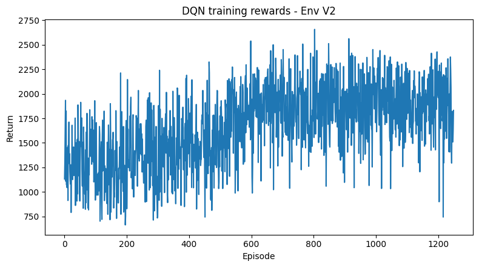

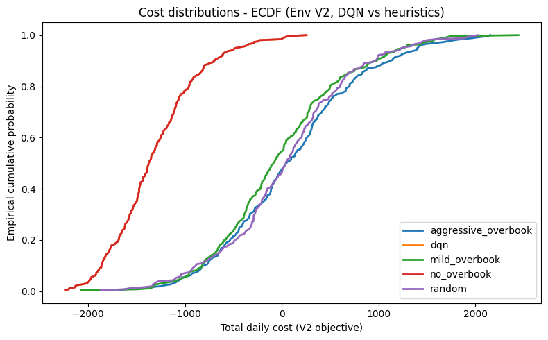

```python
def run_episode_v2(env: ClinicEnvV2, policy_fn):
    obs, info = env.reset()
    total_return = 0.0
    while True:
        a = policy_fn(obs, env)
        obs, r, terminated, truncated, info = env.step(a)
        total_return += float(r)
        if terminated or truncated:
            break
    # core fields already returned by earlier runner
    rec = dict(
        reward=total_return,
        cost_wait=float(info["cost_wait"]),
        cost_overtime=float(info["cost_overtime"]),
        cost_idle=float(info["cost_idle"]),
        cost_no_show=float(info["cost_no_show"]),
        patients_served=int(info["patients_served"]),
        patients_arrived=int(info["patients_arrived"]),
    )
    # V2 extras (from EnvV2.step)
    rec["revenue"] = float(info.get("revenue", 0.0))
    rec["shortfall_penalty"] = float(info.get("shortfall_penalty", 0.0))
    # V2 objective (costs - revenue + penalty)
    if "cost_total_v2" in info:
        rec["cost_total_v2"] = float(info["cost_total_v2"])
    else:
        raw = rec["cost_wait"] + rec["cost_overtime"] + rec["cost_idle"] + rec["cost_no_show"]
        rec["cost_total_v2"] = raw - rec["revenue"] + rec["shortfall_penalty"]
    return rec

def eval_policies_v2(env_cfg: ClinicConfig, policies, episodes: int = 256) -> pd.DataFrame:
    rows = []
    for name, pi in policies.items():
        env = ClinicEnvV2(env_cfg)
        for _ in range(episodes):
            rec = run_episode_v2(env, pi)
            rec["policy"] = name
            rows.append(rec)
    return pd.DataFrame(rows)

@torch.no_grad()
def evaluate_greedy_v2(qnet: QNet, env_cfg: ClinicConfig, episodes=256) -> pd.DataFrame:
    env = ClinicEnvV2(env_cfg)
    def greedy(obs, env):
        x = torch.tensor(obs, dtype=torch.float32, device=device).unsqueeze(0)
        q = qnet(x)
        return int(q.argmax(1).item())
    return pd.DataFrame([run_episode_v2(env, greedy) for _ in range(episodes)])

def summarize_v2(df: pd.DataFrame, alpha: float = 0.05) -> pd.DataFrame:
    out = []
    for name, g in df.groupby("policy"):
        x = g["cost_total_v2"].to_numpy(np.float32)
        v, c = var_cvar(x, alpha=alpha)
        lo, hi = bootstrap_ci(x, np.mean, B=800, alpha=0.05)
        out.append(dict(
            policy=name,
            mean_cost_v2=float(x.mean()),
            mean_cost_v2_ci_lo=float(lo),
            mean_cost_v2_ci_hi=float(hi),
            var5_v2=float(v),
            cvar5_v2=float(c),
            served=float(g["patients_served"].mean()),
            mean_revenue=float(g["revenue"].mean()),
            mean_shortfall_penalty=float(g["shortfall_penalty"].mean()),
        ))
    return pd.DataFrame(out).sort_values("mean_cost_v2")

# train DQN in Env V2 (function from Section 11)
qnet_dqn_v2, logs_dqn_v2 = run_dqn_v2(cfg,
                                      steps_total=40_000,
                                      batch_size=64,
                                      start_learning=1_000,
                                      target_sync=2_000,
                                      gamma=0.99,
                                      lr=1e-3,
                                      print_every=2_000)

# Plot rewards
plt.figure(figsize=(8,4.5))
plt.plot(logs_dqn_v2["rewards"])
plt.xlabel("Episode"); plt.ylabel("Return"); plt.title("DQN training rewards - Env V2")
plt.tight_layout()
path_rewards_v2 = os.path.join(ART_DIR, f"dqn_rewards_envv2_{now_tag()}.png")
plt.savefig(path_rewards_v2, dpi=120)
print("Saved:", path_rewards_v2)

# evaluate baselines and DQN under the V2 objective
df_base_v2 = eval_policies_v2(cfg, POLICIES, episodes=256)
df_dqn_v2 = evaluate_greedy_v2(qnet_dqn_v2, cfg, episodes=256).assign(policy="dqn")
df_all_v2 = pd.concat([df_base_v2, df_dqn_v2], ignore_index=True)

# Summaries (V2)
summary_v2 = summarize_v2(df_all_v2, alpha=0.05)
print(summary_v2)

# ECDF using V2 totals
def ecdf(y: np.ndarray):
    y = np.sort(y.astype(np.float32))
    x = np.linspace(0.0, 1.0, len(y), endpoint=False) + 1.0/len(y)
    return y, x

plt.figure(figsize=(8,5))
for name, g in df_all_v2.groupby("policy"):
    if name not in color_map: continue
    y, x = ecdf(g["cost_total_v2"].to_numpy())
    plt.plot(y, x, label=name, linewidth=2.0, color=color_map[name])
plt.xlabel("Total daily cost (V2 objective)")
plt.ylabel("Empirical cumulative probability")
plt.title("Cost distributions - ECDF (Env V2, DQN vs heuristics)")
plt.legend(); plt.tight_layout()
path_ecdf_all_v2 = os.path.join(ART_DIR, f"ecdf_costs_envv2_{now_tag()}.png")
plt.savefig(path_ecdf_all_v2, dpi=120)
print("Saved:", path_ecdf_all_v2)
```

# 12a Contextual bandit baseline on Env V2

Here the project introduces a simpler learning baseline that treats each slot as an independent contextual bandit rather than a full MDP. For each slot, the algorithm maintains estimated rewards for different overbooking levels and updates them using an ε-greedy rule based on observed outcomes. The bandit is trained and then evaluated in Env V2, and its performance is summarized alongside DQN and the heuristics. This section shows how far a relatively shallow learning method can go when it ignores temporal dynamics and only reacts to local context.

```
                policy  mean_cost_v2  mean_cost_v2_ci_lo  mean_cost_v2_ci_hi  \
2                  dqn  -1311.346069        -1364.624878        -1253.996094
4          no_overbook  -1311.346069        -1364.624878        -1253.996094
3        mild_overbook    -13.819134          -90.508011           67.095917
1     bandit_epsgreedy     34.007034          -54.641155          125.427292
5               random     49.348827          -45.008823          134.227493
0  aggressive_overbook    102.382812            8.918678          191.141724

       var5_v2     cvar5_v2     served
2  -471.300018  -169.438461  54.148438
4  -471.300018  -169.438461  54.148438
3  1253.274902  1578.853760  60.859375
1  1262.449951  1634.453735  60.953125
5  1242.324951  1579.123047  60.777344
0  1403.125000  1738.099854  61.007812
Saved: report_artifacts/ecdf_envv2_bandit_20251124_210948.png
```

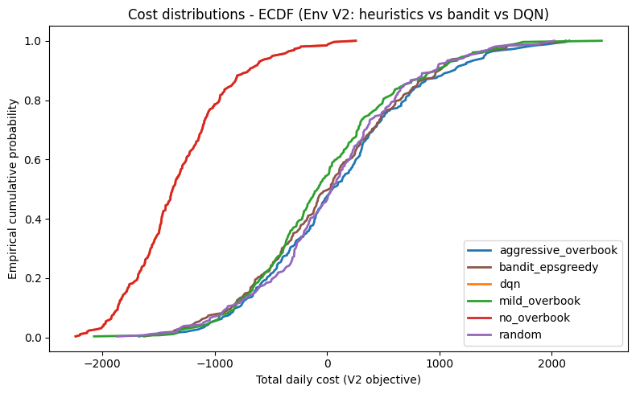

```python
def run_episode_v2_online(env: ClinicEnvV2, act_fn, update_fn=None):
    """
    One Env V2 episode with optional online learning updates per step.
    Returns both raw costs and V2 objective (cost_total_v2).
    """
    obs, _ = env.reset()
    total_reward = 0.0
    while True:
        a = act_fn(obs, env)
        obs2, r, terminated, truncated, info = env.step(a)
        total_reward += float(r)
        if update_fn is not None:
            slot = int(obs[0])               # context = slot index
            update_fn(slot, a, r)
        obs = obs2
        if terminated or truncated:
            break

    rec = dict(
        reward=total_reward,
        cost_wait=float(info["cost_wait"]),
        cost_overtime=float(info["cost_overtime"]),
        cost_idle=float(info["cost_idle"]),
        cost_no_show=float(info["cost_no_show"]),
        patients_served=int(info["patients_served"]),
        patients_arrived=int(info["patients_arrived"]),
        revenue=float(info.get("revenue", 0.0)),
        shortfall_penalty=float(info.get("shortfall_penalty", 0.0)),
    )
    rec["cost_total"] = rec["cost_wait"] + rec["cost_overtime"] + rec["cost_idle"] + rec["cost_no_show"]
    rec["cost_total_v2"] = rec["cost_total"] - rec["revenue"] + rec["shortfall_penalty"]
    return rec

class SlotBandit:
    """
    ε-greedy per-slot bandit. Keeps Q[slot, action] = mean Env V2 step reward.
    Respects feasibility: won’t pick actions that exceed remaining overbooking budget.
    """
    def __init__(self, n_slots: int, n_actions: int, epsilon: float = 0.1, seed: int = SEED):
        self.n_slots = n_slots
        self.n_actions = n_actions
        self.epsilon = float(epsilon)
        self.rng = np.random.default_rng(seed)
        self.Q = np.zeros((n_slots, n_actions), dtype=np.float32)
        self.N = np.zeros((n_slots, n_actions), dtype=np.int32)

    def act(self, obs: np.ndarray, env: ClinicEnvV2) -> int:
        slot = int(obs[0])
        feas = self._feasible_actions(env)
        if self.rng.random() < self.epsilon:
            return int(self.rng.choice(feas))
        q_row = self.Q[slot]
        return int(feas[np.argmax(q_row[feas])])

    def update(self, slot: int, a: int, reward: float):
        self.N[slot, a] += 1
        n = self.N[slot, a]
        self.Q[slot, a] += (float(reward) - self.Q[slot, a]) / max(1, n)

    @staticmethod
    def _feasible_actions(env: ClinicEnvV2):
        max_a = env.action_space.n - 1
        feas = [0]
        if env.overbook_remaining >= env.cfg.discrete_overbook_step and max_a >= 1:
            feas.append(1)
        if env.overbook_remaining >= 2 * env.cfg.discrete_overbook_step and max_a >= 2:
            feas.append(2)
        return np.array(feas, dtype=np.int64)

def train_and_eval_bandit_v2(env_cfg: ClinicConfig,
                             episodes_train=200,
                             episodes_eval=256,
                             epsilon=0.1):
    # train
    env_tr = ClinicEnvV2(env_cfg)
    bandit = SlotBandit(env_tr.cfg.day_slots, env_tr.action_space.n, epsilon=epsilon, seed=SEED)
    def act_tr(obs, env): return bandit.act(obs, env)
    def upd(slot, a, r): bandit.update(slot, a, r)
    train_returns = []
    for _ in range(episodes_train):
        rec = run_episode_v2_online(env_tr, act_tr, update_fn=upd)
        train_returns.append(rec["reward"])

    # evaluate (ε=0)
    env_ev = ClinicEnvV2(env_cfg)
    bandit_eval = SlotBandit(env_ev.cfg.day_slots, env_ev.action_space.n, epsilon=0.0, seed=SEED)
    bandit_eval.Q[:] = bandit.Q
    def act_ev(obs, env): return bandit_eval.act(obs, env)

    rows = [run_episode_v2_online(env_ev, act_ev) | {"policy": "bandit_epsgreedy"} for _ in range(256)]
    return pd.DataFrame(rows), np.array(train_returns, np.float32), bandit

def summarize_v2_any(df: pd.DataFrame, alpha: float = 0.05) -> pd.DataFrame:
    """
    Summarize using V2 objective when present.
    """
    key = "cost_total_v2" if "cost_total_v2" in df.columns else "cost_total"
    out = []
    for name, g in df.groupby("policy"):
        x = g[key].to_numpy(np.float32)
        v, c = var_cvar(x, alpha=alpha)
        lo, hi = bootstrap_ci(x, np.mean, B=800, alpha=0.05)
        out.append(dict(
            policy=name,
            mean_cost_v2=float(x.mean()),
            mean_cost_v2_ci_lo=float(lo),
            mean_cost_v2_ci_hi=float(hi),
            var5_v2=float(v), cvar5_v2=float(c),
            served=float(g["patients_served"].mean()),
        ))
    return pd.DataFrame(out).sort_values("mean_cost_v2")

# Train bandit & compare
df_bandit_v2, bandit_train_returns, bandit_obj = train_and_eval_bandit_v2(cfg, episodes_train=200, episodes_eval=256, epsilon=0.1)

dfs = [df_base_v2, df_bandit_v2]
try:
    dfs.append(df_dqn_v2)   # include DQN from Section 11
except NameError:
    pass
df_compare_v2 = pd.concat(dfs, ignore_index=True)

print(summarize_v2_any(df_compare_v2, alpha=0.05))

# ECDF on V2 objective (adds bandit color)
if "bandit_epsgreedy" not in color_map:
    color_map["bandit_epsgreedy"] = "C5"

plt.figure(figsize=(8,5))
key = "cost_total_v2" if "cost_total_v2" in df_compare_v2.columns else "cost_total"
for name, g in df_compare_v2.groupby("policy"):
    y, x = ecdf(g[key].to_numpy())
    plt.plot(y, x, label=name, linewidth=2.0, color=color_map.get(name, None))
plt.xlabel("Total daily cost (V2 objective)")
plt.ylabel("Empirical cumulative probability")
plt.title("Cost distributions - ECDF (Env V2: heuristics vs bandit vs DQN)")
plt.legend(); plt.tight_layout()
p_ecdf_bandit = os.path.join(ART_DIR, f"ecdf_envv2_bandit_{now_tag()}.png")
plt.savefig(p_ecdf_bandit, dpi=120); print("Saved:", p_ecdf_bandit)
```